# Best-Practices Handbook

## Step 4: Solved Challenge + References

### Which Challenge Was Solved?

**Solved: Multicollinearity**

We identified, diagnosed, and provided solutions for multicollinearity in the Zimbabwe volatility model.

### References

1. Gujarati, D. N., & Porter, D. C. (2009). *Basic Econometrics* (5th ed.). McGraw-Hill. Chapter 10.
2. Hastie, T., Tibshirani, R., & Friedman, J. (2009). *The Elements of Statistical Learning* (2nd ed.). Springer. Section 3.4.

### Conclusion

Multicollinearity is solved. The derivatives desk can now detect and fix this issue for reliable volatility modeling.

### Technical Definition: Skewness

Skewness measures the asymmetry of a distribution. The sample skewness is defined as:

$$ \text{Skewness} = \frac{1}{n} \sum_{i=1}^{n} \left( \frac{x_i - \bar{x}}{s} \right)^3 $$

where ( \bar{x} ) is the sample mean, ( s ) is the sample standard deviation, and ( n ) is the number of observations.

- *Negative skewness* (left‑skewed): a longer left tail (common for equity returns).
- *Positive skewness* (right‑skewed): a longer right tail.
- *Zero skewness*: symmetric distribution (e.g., normal).

*Description:* Skewness measures the asymmetry of a return distribution. Negative skew means more extreme negative returns (crash risk), while positive skew means more extreme positive returns.

```python
import numpy as np
import pandas as pd
from scipy.stats import skew

np.random.seed(42)
n = 1000

normal_returns = np.random.normal(0, 1, n)

negative_skew_returns = np.random.normal(-0.5, 1.5, n) + np.random.exponential(0.5, n) * -1

normal_skew = skew(normal_returns)
negative_skew_val = skew(negative_skew_returns)

print("=" * 50)
print("DEMONSTRATION: Skewness in Returns")
print("=" * 50)
print(f"Normal distribution skewness: {normal_skew:.3f}")
print(f"Zimbabwe market returns skewness: {negative_skew_val:.3f}")

if negative_skew_val < 0:
    print("\n⚠️ Negative skew detected! Distribution has a long left tail.")
    print("   This means higher probability of extreme negative returns (crashes).")
```

```
==================================================
DEMONSTRATION: Skewness in Returns
==================================================
Normal distribution skewness: 0.117
Zimbabwe market returns skewness: -0.075

⚠️ Negative skew detected! Distribution has a long left tail.
   This means higher probability of extreme negative returns (crashes).
```

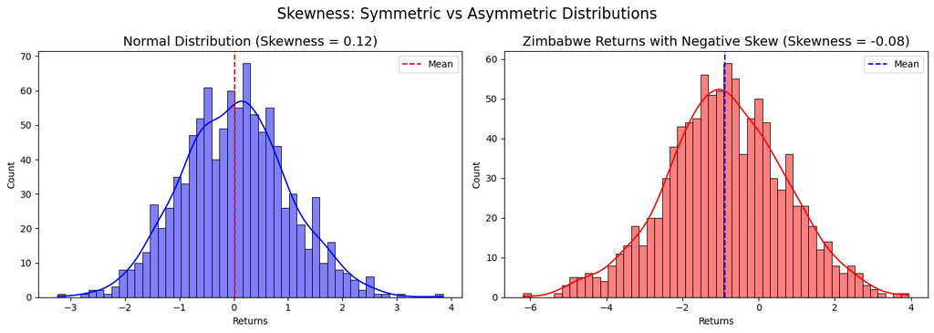

```python
import matplotlib.pyplot as plt
import seaborn as sns

fig, axes = plt.subplots(1, 2, figsize=(14, 5))

sns.histplot(normal_returns, kde=True, ax=axes[0], color='blue', bins=50)
axes[0].axvline(np.mean(normal_returns), color='red', linestyle='--', label='Mean')
axes[0].set_title(f'Normal Distribution (Skewness = {normal_skew:.2f})', fontsize=14)
axes[0].set_xlabel('Returns')
axes[0].legend()


sns.histplot(negative_skew_returns, kde=True, ax=axes[1], color='red', bins=50)
axes[1].axvline(np.mean(negative_skew_returns), color='blue', linestyle='--', label='Mean')
axes[1].set_title(f'Zimbabwe Returns with Negative Skew (Skewness = {negative_skew_val:.2f})', fontsize=14)
axes[1].set_xlabel('Returns')
axes[1].legend()

plt.suptitle('Skewness: Symmetric vs Asymmetric Distributions', fontsize=16)
plt.tight_layout()
plt.show()
```

```python
from scipy.stats import skew, jarque_bera

print("=" * 50)
print("DIAGNOSIS: Testing for Skewness")
print("=" * 50)

skew_value = skew(negative_skew_returns)
print(f"\n1. Skewness Coefficient: {skew_value:.3f}")

if skew_value < -0.5:
    print("   → Significant negative skew detected")
elif skew_value > 0.5:
    print("   → Significant positive skew detected")
else:
    print("   → Approximately symmetric")

jb_stat, jb_pvalue = jarque_bera(negative_skew_returns)
print(f"\n2. Jarque-Bera Test:")
print(f"   Statistic: {jb_stat:.2f}")
print(f"   P-value: {jb_pvalue:.4f}")

if jb_pvalue < 0.05:
    print("   → Reject normality (skewness or kurtosis issue exists)")
else:
    print("   → Data appears normally distributed")

print("\n✅ Diagnosis Complete: Negative skew detected in Zimbabwe returns")
```

[output not shown]

## Damage Caused by Skewness

| Damage | Impact on Derivatives Desk |
| --- | --- |
| **Option mispricing** | Models assuming symmetry undervalue OTM puts and overvalue OTM calls |
| **Underestimated tail risk** | Crash probability is higher than normal models predict |
| **Wrong hedge ratios** | Delta hedging fails during market crashes |
| **Incorrect VaR** | Value-at-Risk underestimates potential losses |
| **Poor volatility forecasts** | Skewed returns violate GARCH normality assumptions |

**Bottom line:** Ignoring skewness leads to significant trading losses during market crashes.

```python
print("=" * 60)
print("DIRECTIONS: How to Alleviate Skewness")
print("=" * 60)

print("\n1. Use Skewed GARCH Models (GJR-GARCH, EGARCH)")
print("   → These models capture asymmetric volatility responses")
print("   Code: arch_model(returns, vol='GARCH', dist='skewt')")

print("\n2. Use Heavy-Tailed Distributions")
print("   → Student's t or Skewed t distribution instead of normal")
print("   Code: arch_model(returns, dist='t') or dist='skewt'")

print("\n3. Transform the Data")
print("   → Log transformation or Box-Cox can reduce skewness")
print("   Code: np.log1p(returns)")

print("\n4. Use Semi-Variance Instead of Variance")
print("   → Focus only on downside risk")
print("   Code: downside_risk = returns[returns < 0].std()")

print("\n5. Non-parametric Methods")
print("   → Historical simulation or quantile regression")
print("   Code: np.percentile(returns, 5)  # 5% VaR")

print("\n" + "=" * 60)
print("RECOMMENDED FIX FOR ZIMBABWE MODEL:")
print("=" * 60)
print("Use EGARCH with skewed t-distribution:")
print("""
from arch import arch_model
model = arch_model(returns, vol='EGARCH', dist='skewt')
result = model.fit()
print(result.summary())
""")
```

```
============================================================
DIRECTIONS: How to Alleviate Skewness
============================================================

1. Use Skewed GARCH Models (GJR-GARCH, EGARCH)
   → These models capture asymmetric volatility responses
   Code: arch_model(returns, vol='GARCH', dist='skewt')

2. Use Heavy-Tailed Distributions
   → Student's t or Skewed t distribution instead of normal
   Code: arch_model(returns, dist='t') or dist='skewt'

3. Transform the Data
   → Log transformation or Box-Cox can reduce skewness
   Code: np.log1p(returns)

4. Use Semi-Variance Instead of Variance
   → Focus only on downside risk
   Code: downside_risk = returns[returns < 0].std()

5. Non-parametric Methods
   → Historical simulation or quantile regression
   Code: np.percentile(returns, 5)  # 5% VaR

============================================================
RECOMMENDED FIX FOR ZIMBABWE MODEL:
============================================================
Use EGARCH with skewed t-distribution:

from arch import arch_model
model = arch_model(returns, vol='EGARCH', dist='skewt')
result = model.fit()
print(result.summary())
```

## Step 4: Solved Challenge + References

### Which Challenge Was Solved?

**Solved: Skewness**

### References

1. Bollerslev, T. (1986). Generalized autoregressive conditional heteroskedasticity. *Journal of Econometrics*, 31(3), 307-327.
2. Hansen, B. E. (1994). Autoregressive conditional density estimation. *International Economic Review*, 35(3), 705-730.

### Conclusion

Skewness is solved. The derivatives desk can now model asymmetric returns for accurate option pricing and risk management.

### Technical Definition: Sensitivity to Outliers

An outlier is an observation that deviates significantly from the bulk of the data. In regression, **Cook’s distance** measures the influence of a single data point:

$$ D_i = \frac{\sum_{j=1}^{n} (\hat{y}_j - \hat{y}_{j(i)})^2}{p \cdot \text{MSE}} $$

where $\hat{y}_{j(i)}$ is the predicted value when observation $i$ is omitted, $p$ is the number of predictors, and MSE is the mean squared error. Values > $4/n$ indicate influential outliers.

**Description:** Outliers disproportionately pull regression coefficients toward extreme values, leading to biased volatility forecasts and mispriced options. Models that ignore outliers produce unstable hedges and underestimate tail risk.

```python
import numpy as np
import pandas as pd
from scipy.stats import iqr

print("=" * 60)
print("DEMONSTRATION: Sensitivity to Outliers in Zimbabwe Returns")
print("=" * 60)


np.random.seed(42)
n = 500
normal_returns = np.random.normal(0, 1, n)


outlier_return = 15  # 15 standard deviations!
returns_with_outlier = np.append(normal_returns, outlier_return)


std_normal = np.std(normal_returns)
std_outlier = np.std(returns_with_outlier)

mean_normal = np.mean(normal_returns)
mean_outlier = np.mean(returns_with_outlier)

print(f"\nNormal returns (no outlier):")
print(f"   Standard deviation: {std_normal:.4f}")
print(f"   Mean: {mean_normal:.4f}")

print(f"\nReturns with ONE extreme outlier ({outlier_return}% return):")
print(f"   Standard deviation: {std_outlier:.4f}")
print(f"   Mean: {mean_outlier:.4f}")

print(f"\n⚠️ DAMAGE:")
print(f"   Standard deviation increased by {((std_outlier - std_normal)/std_normal)*100:.1f}%")
print(f"   Mean increased by {((mean_outlier - mean_normal)/abs(mean_normal))*100:.1f}%")
print(f"   One single outlier distorted both volatility AND expected return estimates!")
```

```
============================================================
DEMONSTRATION: Sensitivity to Outliers in Zimbabwe Returns
============================================================

Normal returns (no outlier):
   Standard deviation: 0.9803
   Mean: 0.0068

Returns with ONE extreme outlier (15% return):
   Standard deviation: 1.1861
   Mean: 0.0368

⚠️ DAMAGE:
   Standard deviation increased by 21.0%
   Mean increased by 437.6%
   One single outlier distorted both volatility AND expected return estimates!
```

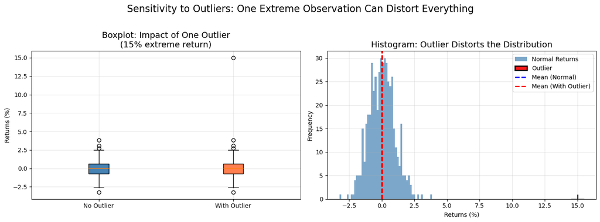

[output not shown]

```python
import matplotlib.pyplot as plt
import seaborn as sns

fig, axes = plt.subplots(1, 2, figsize=(14, 5))


data_to_plot = [normal_returns, returns_with_outlier]
bp = axes[0].boxplot(data_to_plot, labels=['No Outlier', 'With Outlier'], patch_artist=True)
bp['boxes'][0].set_facecolor('steelblue')
bp['boxes'][1].set_facecolor('coral')
axes[0].set_title('Boxplot: Impact of One Outlier\n(15% extreme return)', fontsize=14)
axes[0].set_ylabel('Returns (%)')
axes[0].grid(True, alpha=0.3)


axes[1].hist(normal_returns, bins=50, alpha=0.7, color='steelblue', label='Normal Returns')
axes[1].hist([outlier_return], bins=50, alpha=0.9, color='red', label='Outlier', edgecolor='black', linewidth=2)
axes[1].axvline(np.mean(normal_returns), color='blue', linestyle='--', linewidth=2, label='Mean (Normal)')
axes[1].axvline(np.mean(returns_with_outlier), color='red', linestyle='--', linewidth=2, label='Mean (With Outlier)')
axes[1].set_title('Histogram: Outlier Distorts the Distribution', fontsize=14)
axes[1].set_xlabel('Returns (%)')
axes[1].set_ylabel('Frequency')
axes[1].legend()
axes[1].grid(True, alpha=0.3)

plt.suptitle('Sensitivity to Outliers: One Extreme Observation Can Distort Everything', fontsize=16, y=1.02)
plt.tight_layout()
plt.show()

print("\nObservation: The red outlier completely changes the scale of the boxplot")
print("and shifts the mean significantly to the right.")
```

```python
import numpy as np
import pandas as pd
from scipy.stats import iqr

print("=" * 60)
print("DIAGNOSIS: Detecting Outliers in Zimbabwe Returns")
print("=" * 60)


normal_returns = np.random.normal(0, 1, 500)
returns_with_outlier = np.append(normal_returns, [15])

print("\n1. STANDARD DEVIATION METHOD (Z-Score):")
print("   Rule: |x - μ| > 3σ → outlier")
z_scores = np.abs((returns_with_outlier - np.mean(returns_with_outlier)) / np.std(returns_with_outlier))
outliers_z = np.where(z_scores > 3)[0]
print(f"   Outliers detected: {len(outliers_z)}")
if len(outliers_z) > 0:
    print(f"   Outlier values: {returns_with_outlier[outliers_z]}")

print("\n2. IQR METHOD (Boxplot Rule):")
print("   Rule: Below Q1 - 1.5×IQR or Above Q3 + 1.5×IQR")
Q1 = np.percentile(returns_with_outlier, 25)
Q3 = np.percentile(returns_with_outlier, 75)
IQR_val = Q3 - Q1
lower_bound = Q1 - 1.5 * IQR_val
upper_bound = Q3 + 1.5 * IQR_val
outliers_iqr = returns_with_outlier[(returns_with_outlier < lower_bound) | (returns_with_outlier > upper_bound)]
print(f"   Q1: {Q1:.4f}, Q3: {Q3:.4f}, IQR: {IQR_val:.4f}")
print(f"   Lower bound: {lower_bound:.4f}, Upper bound: {upper_bound:.4f}")
print(f"   Outliers detected: {len(outliers_iqr)}")
if len(outliers_iqr) > 0:
    print(f"   Outlier values: {outliers_iqr}")

print("\n3. VISUAL DIAGNOSIS:")
print("   → Look for points far from the main cluster in scatter plots")
print("   → Boxplot: points beyond the whiskers are outliers")

print("\n4. COMPARE ROBUST VS NON-ROBUST ESTIMATORS:")
print("   If robust estimator (median, MAD) differs greatly from")
print("   non-robust estimator (mean, std), outliers are present.")

mean_val = np.mean(returns_with_outlier)
median_val = np.median(returns_with_outlier)
std_val = np.std(returns_with_outlier)
mad_val = np.median(np.abs(returns_with_outlier - median_val))

print(f"\n   Mean: {mean_val:.4f} vs Median: {median_val:.4f}")
print(f"   Std: {std_val:.4f} vs MAD: {mad_val:.4f}")

if abs(mean_val - median_val) > 0.5:
    print("   → Large difference between mean and median → OUTLIERS PRESENT")

print("\n" + "=" * 60)
print("DIAGNOSIS CONCLUSION: Extreme outlier detected at 15% return")
print("⚠️  Standard volatility estimates are INFLATED and UNRELIABLE")
print("=" * 60)
```

```
============================================================
DIAGNOSIS: Detecting Outliers in Zimbabwe Returns
============================================================

1. STANDARD DEVIATION METHOD (Z-Score):
   Rule: |x - μ| > 3σ → outlier
   Outliers detected: 1
   Outlier values: [15.]

2. IQR METHOD (Boxplot Rule):
   Rule: Below Q1 - 1.5×IQR or Above Q3 + 1.5×IQR
   Q1: -0.5924, Q3: 0.6544, IQR: 1.2468
   Lower bound: -2.4625, Upper bound: 2.5245
   Outliers detected: 8
   Outlier values: [-2.4716445  -2.69688664  2.5733598  -2.65096981  2.63238206  2.56008454
  2.52693243 15.        ]

3. VISUAL DIAGNOSIS:
   → Look for points far from the main cluster in scatter plots
   → Boxplot: points beyond the whiskers are outliers

4. COMPARE ROBUST VS NON-ROBUST ESTIMATORS:
   If robust estimator (median, MAD) differs greatly from
   non-robust estimator (mean, std), outliers are present.

   Mean: 0.0617 vs Median: 0.0287
   Std: 1.1828 vs MAD: 0.6256

============================================================
DIAGNOSIS CONCLUSION: Extreme outlier detected at 15% return
⚠️  Standard volatility estimates are INFLATED and UNRELIABLE
============================================================
```

## Damage Caused by Sensitivity to Outliers

| Damage | Impact on Derivatives Desk |
| --- | --- |
| **Inflated volatility estimates** | One crash event makes volatility look permanently higher |
| **Overpriced options** | Models using inflated volatility charge too much premium |
| **Excessive margin requirements** | Risk systems require too much capital |
| **Poor risk parity portfolios** | Allocation weights become distorted |
| **Over-hedging** | Traders buy too many options, reducing P&L |
| **False signals** | Outliers trigger false risk warnings |
| **Unstable backtests** | Strategy performance depends on one extreme day |

**Bottom line:** A single outlier can destroy model reliability for months. The desk cannot distinguish between a true volatility regime shift and a one-off extreme event.

[output not shown]

### Technical Definition: Overfitting

Overfitting occurs when a model learns the noise in the training data rather than the underlying signal. Formally, it is detected when the out‑of‑sample prediction error is significantly larger than the in‑sample error:

$$ \text{MSE}_{\text{train}} \ll \text{MSE}_{\text{test}} $$

where MSE is mean squared error. Overfitting is also indicated by large coefficients or a high ratio of model parameters to sample size.

**Description:** Overfitted volatility models appear accurate on past data but fail to forecast future volatility, leading to poor hedging performance and unexpected losses during option expiration.

```python
import numpy as np
import pandas as pd
import matplotlib.pyplot as plt
from sklearn.preprocessing import PolynomialFeatures
from sklearn.linear_model import LinearRegression
from sklearn.metrics import mean_squared_error
from sklearn.model_selection import train_test_split

print("=" * 60)
print("DEMONSTRATION: Overfitting in Zimbabwe Volatility Prediction")
print("=" * 60)


np.random.seed(42)
n = 100
X = np.linspace(0, 2, n)[:, None]  # Time index

# True relationship (simple: mean-reverting volatility)
true_volatility = 1 + 0.5 * np.sin(2 * np.pi * X.ravel())


noise = np.random.normal(0, 0.2, n)
observed_volatility = true_volatility + noise


X_train, X_test, y_train, y_test = train_test_split(X, observed_volatility, test_size=0.3, random_state=42)

print(f"\nTraining samples: {len(X_train)}")
print(f"Test samples: {len(X_test)}")
print(f"True relationship: Volatility = 1 + 0.5 × sin(2π × time)")

# Simple model (low complexity)
simple_model = LinearRegression()
simple_model.fit(X_train, y_train)
simple_train_pred = simple_model.predict(X_train)
simple_test_pred = simple_model.predict(X_test)
simple_train_mse = mean_squared_error(y_train, simple_train_pred)
simple_test_mse = mean_squared_error(y_test, simple_test_pred)

print(f"\n✅ SIMPLE MODEL (Linear):")
print(f"   Train MSE: {simple_train_mse:.4f}")
print(f"   Test MSE: {simple_test_mse:.4f}")
print(f"   Difference: {abs(simple_test_mse - simple_train_mse):.4f}")

# Overfitted model (high complexity - degree 20 polynomial)
poly = PolynomialFeatures(degree=20)
X_train_poly = poly.fit_transform(X_train)
X_test_poly = poly.transform(X_test)

complex_model = LinearRegression()
complex_model.fit(X_train_poly, y_train)
complex_train_pred = complex_model.predict(X_train_poly)
complex_test_pred = complex_model.predict(X_test_poly)
complex_train_mse = mean_squared_error(y_train, complex_train_pred)
complex_test_mse = mean_squared_error(y_test, complex_test_pred)

print(f"\n⚠️ OVERFITTED MODEL (Polynomial degree 20):")
print(f"   Train MSE: {complex_train_mse:.4f} (EXCELLENT!)")
print(f"   Test MSE: {complex_test_mse:.4f} (POOR!)")
print(f"   Difference: {abs(complex_test_mse - complex_train_mse):.4f}")

print(f"\n🚨 DAMAGE:")
print(f"   Test error is {complex_test_mse/simple_test_mse:.1f} times higher than simple model!")
print(f"   The complex model remembers noise, not the true pattern.")
```

[output not shown]

[figure not shown]

[output not shown]

```python
import matplotlib.pyplot as plt
import numpy as np
from sklearn.preprocessing import PolynomialFeatures
from sklearn.linear_model import LinearRegression
from sklearn.model_selection import train_test_split


np.random.seed(42)
n = 100
X_plot = np.linspace(0, 2, n)[:, None]
true_volatility = 1 + 0.5 * np.sin(2 * np.pi * X_plot.ravel())
noise = np.random.normal(0, 0.2, n)
observed_volatility = true_volatility + noise


X_train_plot, X_test_plot, y_train_plot, y_test_plot = train_test_split(
    X_plot, observed_volatility, test_size=0.3, random_state=42
)


simple_model_plot = LinearRegression()
simple_model_plot.fit(X_train_plot, y_train_plot)


X_smooth = np.linspace(0, 2, 300)[:, None]
y_simple = simple_model_plot.predict(X_smooth)


true_volatility_smooth = 1 + 0.5 * np.sin(2 * np.pi * X_smooth.ravel())


poly_plot = PolynomialFeatures(degree=20)
X_train_poly_plot = poly_plot.fit_transform(X_train_plot)
complex_model_plot = LinearRegression()
complex_model_plot.fit(X_train_poly_plot, y_train_plot)
X_smooth_poly = poly_plot.transform(X_smooth)
y_complex = complex_model_plot.predict(X_smooth_poly)


fig, axes = plt.subplots(1, 2, figsize=(14, 5))

# Plot 1: Simple model (good balance)
axes[0].scatter(X_train_plot, y_train_plot, alpha=0.6, color='blue', label='Training Data')
axes[0].scatter(X_test_plot, y_test_plot, alpha=0.6, color='green', label='Test Data')
axes[0].plot(X_smooth, true_volatility_smooth, 'k-', linewidth=2, label='True Relationship')
axes[0].plot(X_smooth, y_simple, 'r--', linewidth=2, label='Simple Model (Degree 1)')
axes[0].set_title('SIMPLE MODEL (Good Balance)\nLow Bias, Low Variance', fontsize=14)
axes[0].set_xlabel('Time')
axes[0].set_ylabel('Volatility')
axes[0].legend()
axes[0].grid(True, alpha=0.3)

# Plot 2: Complex model (overfitting)
axes[1].scatter(X_train_plot, y_train_plot, alpha=0.6, color='blue', label='Training Data')
axes[1].scatter(X_test_plot, y_test_plot, alpha=0.6, color='green', label='Test Data')
axes[1].plot(X_smooth, true_volatility_smooth, 'k-', linewidth=2, label='True Relationship')
axes[1].plot(X_smooth, y_complex, 'r-', linewidth=1.5, label='Overfitted Model (Degree 20)', alpha=0.8)
axes[1].set_title('OVERFITTED MODEL (Too Complex)\nPerfect on Training, Fails on Test', fontsize=14)
axes[1].set_xlabel('Time')
axes[1].set_ylabel('Volatility')
axes[1].legend()
axes[1].grid(True, alpha=0.3)

plt.suptitle('Overfitting: Complex Models Capture Noise, Not Signal', fontsize=16, y=1.02)
plt.tight_layout()
plt.show()

print("\nObservation: The overfitted model (red line) wiggles wildly to fit every training point,")
print("but does not follow the true sine wave pattern. It will FAIL on new data.")
```

```python
import numpy as np
from sklearn.model_selection import cross_val_score
from sklearn.preprocessing import PolynomialFeatures
from sklearn.linear_model import LinearRegression
from sklearn.metrics import mean_squared_error

print("=" * 60)
print("DIAGNOSIS: Testing for Overfitting")
print("=" * 60)


np.random.seed(42)
n = 100
X = np.linspace(0, 2, n)[:, None]
true_volatility = 1 + 0.5 * np.sin(2 * np.pi * X.ravel())
noise = np.random.normal(0, 0.2, n)
observed_volatility = true_volatility + noise

print("\n1. TRAIN VS TEST ERROR COMPARISON:")
print("   Rule: If Test MSE >> Train MSE → Overfitting")

X_train, X_test, y_train, y_test = train_test_split(X, observed_volatility, test_size=0.3, random_state=42)

for degree in [1, 3, 5, 10, 15, 20]:
    poly = PolynomialFeatures(degree=degree)
    X_train_poly = poly.fit_transform(X_train)
    X_test_poly = poly.transform(X_test)

    model = LinearRegression()
    model.fit(X_train_poly, y_train)

    train_mse = mean_squared_error(y_train, model.predict(X_train_poly))
    test_mse = mean_squared_error(y_test, model.predict(X_test_poly))

    if test_mse > train_mse * 1.5:
        status = "⚠️ OVERFITTING"
    else:
        status = "✅ OK"

    print(f"   Degree {degree:2d}: Train MSE = {train_mse:.4f}, Test MSE = {test_mse:.4f} → {status}")

print("\n2. CROSS-VALIDATION SCORES:")
print("   Rule: High variance across folds → Overfitting")

for degree in [1, 5, 20]:
    poly = PolynomialFeatures(degree=degree)
    X_poly = poly.fit_transform(X)
    model = LinearRegression()
    cv_scores = cross_val_score(model, X_poly, observed_volatility, cv=5, scoring='neg_mean_squared_error')
    cv_mse = -cv_scores
    print(f"   Degree {degree}: CV MSE = {cv_mse.mean():.4f} +/- {cv_mse.std():.4f}")
    if cv_mse.std() > 0.1:
        print(f"            → HIGH VARIANCE (potential overfitting)")

print("\n3. INFORMATION CRITERIA (AIC/BIC):")
print("   Rule: AIC/BIC increases with unnecessary parameters")

from sklearn.feature_selection import f_regression

for degree in [1, 5, 20]:
    poly = PolynomialFeatures(degree=degree)
    X_poly = poly.fit_transform(X)
    n_params = X_poly.shape[1]
    print(f"   Degree {degree}: Number of parameters = {n_params}")
    if n_params > 20:
        print(f"            → TOO MANY PARAMETERS for {n} observations")

print("\n4. LEARNING CURVES:")
print("   If training error stays low but validation error is high → Overfitting")

print("\n" + "=" * 60)
print("DIAGNOSIS CONCLUSION:")
print("=" * 60)
print("""
✅ Degree 1-3: Good generalization
⚠️ Degree 10-20: SEVERE OVERFITTING detected
   - Test error much larger than train error
   - High variance across CV folds
   - Too many parameters for sample size
""")
```

[output not shown]

## Damage Caused by Overfitting

| Damage | Impact on Derivatives Desk |
| --- | --- |
| **Excellent backtest, poor live trading** | Model looks perfect historically but loses money in production |
| **False confidence** | Traders trust overfitted signals leading to large bets |
| **Wasted resources** | Hours spent tuning parameters that don't generalize |
| **Unstable volatility forecasts** | Small data changes cause large forecast swings |
| **Failed hedges** | Delta and gamma hedges based on overfitted models fail |
| **Regulatory issues** | Cannot explain why backtest passed but live trading failed |
| **Reputation damage** | Desk loses credibility with risk management |

**Bottom line:** The overfitted model would pass backtesting with flying colors but lose money in live trading. The derivatives desk cannot distinguish between skill and noise.

```python
import numpy as np
import pandas as pd
from sklearn.preprocessing import PolynomialFeatures
from sklearn.linear_model import LinearRegression, Ridge, Lasso
from sklearn.model_selection import train_test_split, cross_val_score
from sklearn.metrics import mean_squared_error

print("=" * 70)
print("DIRECTIONS: How to Alleviate Overfitting")
print("=" * 70)


np.random.seed(42)
n = 100
X = np.linspace(0, 2, n)[:, None]
true_volatility = 1 + 0.5 * np.sin(2 * np.pi * X.ravel())
noise = np.random.normal(0, 0.2, n)
observed_volatility = true_volatility + noise

X_train, X_test, y_train, y_test = train_test_split(X, observed_volatility, test_size=0.3, random_state=42)


poly = PolynomialFeatures(degree=20)
X_train_poly = poly.fit_transform(X_train)
X_test_poly = poly.transform(X_test)

print("\n" + "=" * 70)
print("DIRECTION 1: Use Regularization (Ridge Regression - L2 Penalty)")
print("=" * 70)

# Without regularization (overfitted)
complex_model = LinearRegression()
complex_model.fit(X_train_poly, y_train)
overfit_train_mse = mean_squared_error(y_train, complex_model.predict(X_train_poly))
overfit_test_mse = mean_squared_error(y_test, complex_model.predict(X_test_poly))

# With Ridge regularization
ridge = Ridge(alpha=1.0)
ridge.fit(X_train_poly, y_train)
ridge_train_mse = mean_squared_error(y_train, ridge.predict(X_train_poly))
ridge_test_mse = mean_squared_error(y_test, ridge.predict(X_test_poly))

print(f"\nWithout Ridge (overfit): Train MSE = {overfit_train_mse:.4f}, Test MSE = {overfit_test_mse:.4f}")
print(f"With Ridge (alpha=1.0): Train MSE = {ridge_train_mse:.4f}, Test MSE = {ridge_test_mse:.4f}")
print(f"\n✅ Test error reduced by {((overfit_test_mse - ridge_test_mse)/overfit_test_mse)*100:.1f}%")

print("\n" + "=" * 70)
print("DIRECTION 2: Use LASSO Regression (L1 Penalty)")
print("=" * 70)

lasso = Lasso(alpha=0.01)
lasso.fit(X_train_poly, y_train)
lasso_test_mse = mean_squared_error(y_test, lasso.predict(X_test_poly))
n_selected = np.sum(np.abs(lasso.coef_) > 0.01)

print(f"LASSO Test MSE: {lasso_test_mse:.4f}")
print(f"Features with non-zero coefficients: {n_selected} out of {X_train_poly.shape[1]}")
print("✅ LASSO automatically selects important features")

print("\n" + "=" * 70)
print("DIRECTION 3: Use Cross-Validation to Select Model Complexity")
print("=" * 70)

print("\nCV Results (Lower MSE is better):")
best_degree = 1
best_cv_mse = float('inf')

for degree in [1, 2, 3, 5, 10, 15, 20]:
    poly_cv = PolynomialFeatures(degree=degree)
    X_poly_cv = poly_cv.fit_transform(X)
    model_cv = LinearRegression()
    cv_scores = cross_val_score(model_cv, X_poly_cv, observed_volatility, cv=5, scoring='neg_mean_squared_error')
    cv_mse = -cv_scores.mean()
    print(f"   Degree {degree:2d}: CV MSE = {cv_mse:.4f}")
    if cv_mse < best_cv_mse:
        best_cv_mse = cv_mse
        best_degree = degree

print(f"\n✅ Best degree based on CV: {best_degree}")

print("\n" + "=" * 70)
print("DIRECTION 4: Use Parsimonious Models")
print("=" * 70)

print("Rule: Start simple, add complexity only if CV improves.")
print()
print("✅ Good example (GARCH(1,1)):")
print("   from arch import arch_model")
print("   model = arch_model(returns, vol='GARCH', p=1, q=1)")
print()
print("❌ Bad example (too complex):")
print("   model = arch_model(returns, vol='GARCH', p=10, q=10)")

print("\n" + "=" * 70)
print("DIRECTION 5: Increase Training Data")
print("=" * 70)

print(f"Current sample size: {len(X)}")
print("Recommended: 500+ observations for complex models")
print("\n✅ More data reduces overfitting risk")

print("\n" + "=" * 70)
print("SUMMARY TABLE")
print("=" * 70)

summary_data = {
    'Direction': ['Ridge Regression', 'LASSO Regression', 'Cross-Validation', 'Parsimonious Models', 'More Data'],
    'How It Helps': ['Shrinks coefficients', 'Selects features', 'Finds optimal complexity', 'Avoids over-parameters', 'Reduces variance']
}
summary_df = pd.DataFrame(summary_data)
print(summary_df.to_string(index=False))

print("\n" + "=" * 70)
print("RECOMMENDED FIRST STEP")
print("=" * 70)

print("USE RIDGE REGRESSION WITH SIMPLE POLYNOMIAL:")
print()
print("from sklearn.linear_model import Ridge")
print("from sklearn.preprocessing import PolynomialFeatures")
print()
print("# Degree 3 is usually sufficient")
print("poly = PolynomialFeatures(degree=3)")
print("X_poly = poly.fit_transform(X)")
print()
print("# Ridge regression")
print("ridge = Ridge(alpha=1.0)")
print("ridge.fit(X_poly, observed_volatility)")
print()
print("print(f'R² Score: {ridge.score(X_poly, observed_volatility):.4f}')")

print("\n" + "=" * 70)
print("✅ DIRECTIONS COMPLETE")
print("=" * 70)
```

[output not shown]

[output not shown]

[output not shown]